# Foundations for statistical inference - Sampling distributions

In this lab, you will investigate the ways in which the statistics from a random sample of data can serve as point estimates for population parameters. We’re interested in formulating a *sampling distribution* of our estimate in order to learn about the properties of the estimate, such as its distribution.

**Setting a seed:** We will take some random samples and build sampling distributions in this lab, which means you should set a seed at the start of your lab. If this concept is new to you, review the lab on probability.

## Getting Started

### Load packages

In this lab, we will explore and visualize the data using the **tidyverse** suite of packages. We will also use the **infer** package for resampling.

Let’s load the packages.

```r
library(tidyverse)
library(openintro)
library(infer)
```

### The data

A 2019 Gallup report states the following:

> The premise that scientific progress benefits people has been embodied in discoveries throughout the ages – from the development of vaccinations to the explosion of technology in the past few decades, resulting in billions of supercomputers now resting in the hands and pockets of people worldwide. Still, not everyone around the world feels science benefits them personally.

> **Source:** [World Science Day: Is Knowledge Power?](https://news.gallup.com/opinion/gallup/268121/world-science-day-knowledge-power.aspx)

The Wellcome Global Monitor finds that 20% of people globally do not believe that the work scientists do benefits people like them. In this lab, you will assume this 20% is a true population proportion and learn about how sample proportions can vary from sample to sample by taking smaller samples from the population. We will first create our population assuming a population size of 100,000. This means 20,000 (20%) of the population think the work scientists do does not benefit them personally and the remaining 80,000 think it does.

```r
global_monitor <- tibble(
  scientist_work = c(rep("Benefits", 80000), rep("Doesn't benefit", 20000))
)
```

The name of the data frame is `global_monitor` and the name of the variable that contains responses to the question *“Do you believe that the work scientists do benefit people like you?”* is `scientist_work`.

We can quickly visualize the distribution of these responses using a bar plot.

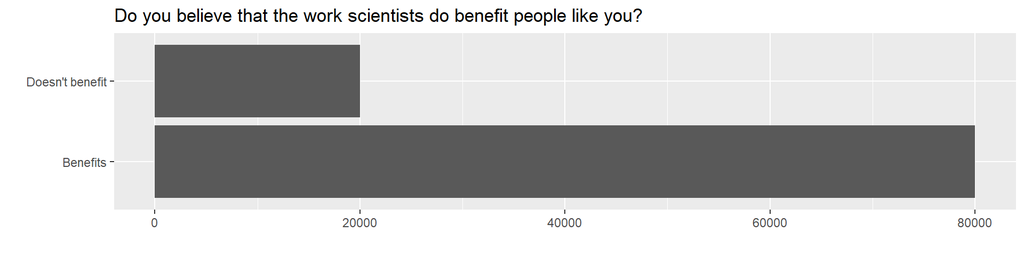

```r
ggplot(global_monitor, aes(x = scientist_work)) +
  geom_bar() +
  labs(
    x = "", y = "",
    title = "Do you believe that the work scientists do benefit people like you?"
  ) +
  coord_flip()
```

We can also obtain summary statistics to confirm we constructed the data frame correctly.

```r
global_monitor %>%
  count(scientist_work) %>%
  mutate(p = n /sum(n))
```

| scientist_work | n | p |
| --- | --- | --- |
| Benefits | 80000 | 0.8 |
| Doesn't benefit | 20000 | 0.2 |

## The unknown sampling distribution

In this lab, you have access to the entire population, but this is rarely the case in real life. Gathering information on an entire population is often extremely costly or impossible. Because of this, we often take a sample of the population and use that to understand the properties of the population.

If you are interested in estimating the proportion of people who don’t think the work scientists do benefits them, you can use the `sample_n` command to survey the population.

```r
samp1 <- global_monitor %>%
  sample_n(50)
```

This command collects a simple random sample of size 50 from the `global_monitor` dataset, and assigns the result to `samp1`. This is similar to randomly drawing names from a hat that contains the names of all in the population. Working with these 50 names is considerably simpler than working with all 100,000 people in the population.

1. Describe the distribution of responses in this sample. How does it compare to the distribution of responses in the population. **Hint:** Although the `sample_n` function takes a random sample of observations (i.e. rows) from the dataset, you can still refer to the variables in the dataset with the same names. Code you presented earlier for visualizing and summarizing the population data will still be useful for the sample, however be careful to not label your proportion `p` since you’re now calculating a sample statistic, not a population parameters. You can customize the label of the statistics to indicate that it comes from the sample.

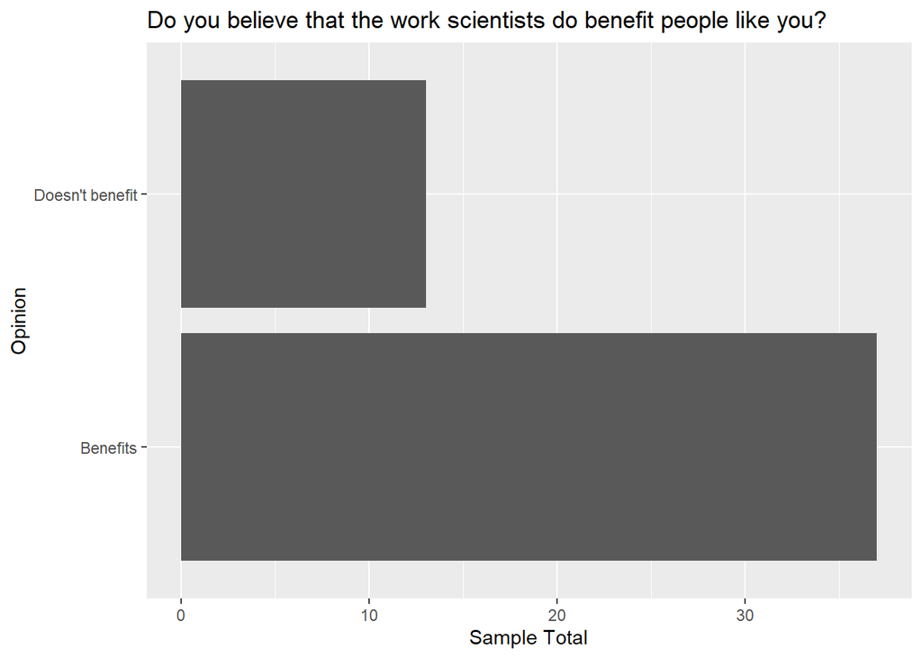

```r
ggplot(samp1, aes(x = scientist_work)) +
  geom_bar() +
  labs(
    x = "Opinion", y = "Sample Total",
    title = "Do you believe that the work scientists do benefit people like you?"
  ) +
  coord_flip()
```

```r
samp1 %>%
  count(scientist_work) %>%
  mutate(samp_p = n /sum(n))
```

| scientist_work | n | samp_p |
| --- | --- | --- |
| Benefits | 37 | 0.74 |
| Doesn't benefit | 13 | 0.26 |

I disocvered through this lab that dpylr’s sample function will not respect the seed unless it’s placed together in the same chunk. However, calling the seed once seems to work properly when knitting the file, as the output in the knitted file is the same each time. Using the knitted files values, the distribution in the sample, while not the same as the overall populations, are very similar. We have .74 for benefits and .26 for doesn’t benefit.

If you’re interested in estimating the proportion of all people who do not believe that the work scientists do benefits them, but you do not have access to the population data, your best single guess is the sample mean.

```r
samp1 %>%
  count(scientist_work) %>%
  mutate(p_hat = n /sum(n))
```

| scientist_work | n | p_hat |
| --- | --- | --- |
| Benefits | 37 | 0.74 |
| Doesn't benefit | 13 | 0.26 |

2. Would you expect the sample proportion to match the sample proportion of another student’s sample? Why, or why not? If the answer is no, would you expect the proportions to be somewhat different or very different? Ask a student team to confirm your answer. | I would expect them to match, as we are all using the same pre-selected seed.
3. Take a second sample, also of size 50, and call it `samp2`. How does the sample proportion of `samp2` compare with that of `samp1`? Suppose we took two more samples, one of size 100 and one of size 1000. Which would you think would provide a more accurate estimate of the population proportion? | I would assume that the closer we approach the original population size, the more often our sample distribution will match our original distribution.

```r
samp2 <- global_monitor %>%
  sample_n(50)

samp2 %>%
  count(scientist_work) %>%
  mutate(p_hat = n /sum(n))
```

| scientist_work | n | p_hat |
| --- | --- | --- |
| Benefits | 42 | 0.84 |
| Doesn't benefit | 8 | 0.16 |

```r
samp3 <- global_monitor %>%
  sample_n(100)

samp3 %>%
  count(scientist_work) %>%
  mutate(p_hat = n /sum(n))
```

| scientist_work | n | p_hat |
| --- | --- | --- |
| Benefits | 81 | 0.81 |
| Doesn't benefit | 19 | 0.19 |

```r
samp4 <- global_monitor %>%
  sample_n(1000)

samp4 %>%
  count(scientist_work) %>%
  mutate(p_hat = n /sum(n))
```

| scientist_work | n | p_hat |
| --- | --- | --- |
| Benefits | 798 | 0.798 |
| Doesn't benefit | 202 | 0.202 |

Not surprisingly, every time you take another random sample, you might get a different sample proportion. It’s useful to get a sense of just how much variability you should expect when estimating the population mean this way. The distribution of sample proportions, called the *sampling distribution (of the proportion)*, can help you understand this variability. In this lab, because you have access to the population, you can build up the sampling distribution for the sample proportion by repeating the above steps many times. Here, we use R to take 15,000 different samples of size 50 from the population, calculate the proportion of responses in each sample, filter for only the *Doesn’t benefit* responses, and store each result in a vector called `sample_props50`. Note that we specify that `replace = TRUE` since sampling distributions are constructed by sampling with replacement.

```r
sample_props50 <- global_monitor %>%
                    rep_sample_n(size = 50, reps = 15000, replace = TRUE) %>%
                    count(scientist_work) %>%
                    mutate(p_hat = n /sum(n)) %>%
                    filter(scientist_work == "Doesn't benefit")
```

And we can visualize the distribution of these proportions with a histogram.

```r
ggplot(data = sample_props50, aes(x = p_hat)) +
  geom_histogram(binwidth = 0.02) +
  labs(
    x = "p_hat (Doesn't benefit)",
    title = "Sampling distribution of p_hat",
    subtitle = "Sample size = 50, Number of samples = 15000"
  )
```

[output not shown]

Next, you will review how this set of code works.

4. How many elements are there in `sample_props50`? Describe the sampling distribution, and be sure to specifically note its center. Make sure to include a plot of the distribution in your answer.

We have 15,000 elements inside sample_props50. It has a center at .2 with a median of .2 and a mean of .199, very close to .2. It appears to be a normal distribution with a clean standard deviation and healthy set of quantiles.

```r
mosaic::favstats(sample_props50$p_hat)
```

|  | min | Q1 | median | Q3 | max | mean | sd | n | missing |
| --- | --- | --- | --- | --- | --- | --- | --- | --- | --- |
|  | 0.02 | 0.16 | 0.2 | 0.24 | 0.42 | 0.1991827 | 0.05678545 | 15000 | 0 |

## Interlude: Sampling distributions

The idea behind the `rep_sample_n` function is *repetition*. Earlier, you took a single sample of size `n` (50) from the population of all people in the population. With this new function, you can repeat this sampling procedure `rep` times in order to build a distribution of a series of sample statistics, which is called the **sampling distribution**.

Note that in practice one rarely gets to build true sampling distributions, because one rarely has access to data from the entire population.

Without the `rep_sample_n` function, this would be painful. We would have to manually run the following code 15,000 times

```r
global_monitor %>%
  sample_n(size = 50, replace = TRUE) %>%
  count(scientist_work) %>%
  mutate(p_hat = n /sum(n)) %>%
  filter(scientist_work == "Doesn't benefit")
```

| scientist_work | n | p_hat |
| --- | --- | --- |
| Doesn't benefit | 11 | 0.22 |

as well as store the resulting sample proportions each time in a separate vector.

Note that for each of the 15,000 times we computed a proportion, we did so from a **different** sample!

5. To make sure you understand how sampling distributions are built, and exactly what the `rep_sample_n` function does, try modifying the code to create a sampling distribution of **25 sample proportions** from **samples of size 10**, and put them in a data frame named `sample_props_small`. Print the output. How many observations are there in this object called `sample_props_small`? What does each observation represent?

```r
sample_props10 <- global_monitor %>%
                    rep_sample_n(size =10 , reps = 25, replace = TRUE) %>%
                    count(scientist_work) %>%
                    mutate(p_hat = n /sum(n)) %>%
                    filter(scientist_work == "Doesn't benefit")
sample_props10
```

| replicate | scientist_work | n | p_hat |
| --- | --- | --- | --- |
| 1 | Doesn't benefit | 2 | 0.2 |
| 2 | Doesn't benefit | 4 | 0.4 |
| 3 | Doesn't benefit | 5 | 0.5 |
| 5 | Doesn't benefit | 2 | 0.2 |
| 6 | Doesn't benefit | 1 | 0.1 |
| 7 | Doesn't benefit | 5 | 0.5 |
| 9 | Doesn't benefit | 1 | 0.1 |
| 10 | Doesn't benefit | 1 | 0.1 |
| 11 | Doesn't benefit | 2 | 0.2 |
| 12 | Doesn't benefit | 4 | 0.4 |

[output cut: 12 more lines]

```r
mosaic::favstats(sample_props10$p_hat)
```

|  | min | Q1 | median | Q3 | max | mean | sd | n | missing |
| --- | --- | --- | --- | --- | --- | --- | --- | --- | --- |
|  | 0.1 | 0.2 | 0.2 | 0.3 | 0.5 | 0.2545455 | 0.126217 | 22 | 0 |

## Sample size and the sampling distribution

Mechanics aside, let’s return to the reason we used the `rep_sample_n` function: to compute a sampling distribution, specifically, the sampling distribution of the proportions from samples of 50 people.

```r
ggplot(data = sample_props50, aes(x = p_hat)) +
  geom_histogram(binwidth = 0.02)
```

[output not shown]

The sampling distribution that you computed tells you much about estimating the true proportion of people who think that the work scientists do doesn’t benefit them. Because the sample proportion is an unbiased estimator, the sampling distribution is centered at the true population proportion, and the spread of the distribution indicates how much variability is incurred by sampling only 50 people at a time from the population.

In the remainder of this section, you will work on getting a sense of the effect that sample size has on your sampling distribution.

6. Use the app below to create sampling distributions of proportions of *Doesn’t benefit* from samples of size 10, 50, and 100. Use 5,000 simulations. What does each observation in the sampling distribution represent? How does the mean, standard error, and shape of the sampling distribution change as the sample size increases? How (if at all) do these values change if you increase the number of simulations? (You do not need to include plots in your answer.)

Each observation is a random sample from the original population. As the sample size increases, all those values become further standardized around the original value of overall population data. In doing so, the error also decreases. As we increase the number of simulation, the same change will occur.

## More Practice

So far, you have only focused on estimating the proportion of those you think the work scientists doesn’t benefit them. Now, you’ll try to estimate the proportion of those who think it does.

Note that while you might be able to answer some of these questions using the app, you are expected to write the required code and produce the necessary plots and summary statistics. You are welcome to use the app for exploration.

7. Take a sample of size 15 from the population and calculate the proportion of people in this sample who think the work scientists do enhances their lives. Using this sample, what is your best point estimate of the population proportion of people who think the work scientists do enchances their lives?

```r
set.seed(1234)

global_monitor %>%
  sample_n(15)  %>%
  count(scientist_work) %>%
  mutate(p_hat = n /sum(n))
```

| scientist_work | n | p_hat |
| --- | --- | --- |
| Benefits | 11 | 0.7333333 |
| Doesn't benefit | 4 | 0.2666667 |

8. Since you have access to the population, simulate the sampling distribution of proportion of those who think the work scientists do enchances their lives for samples of size 15 by taking 2000 samples from the population of size 15 and computing 2000 sample proportions. Store these proportions in as `sample_props15`. Plot the data, then describe the shape of this sampling distribution. Based on this sampling distribution, what would you guess the true proportion of those who think the work scientists do enchances their lives to be? Finally, calculate and report the population proportion.

```r
set.seed(1234)

sample_props15 <- global_monitor %>%
  rep_sample_n(size = 15, reps = 2000, replace = TRUE) %>%
  count(scientist_work) %>%
  mutate(p_hat = n /sum(n)) %>%
  filter(scientist_work == "Benefits")
```

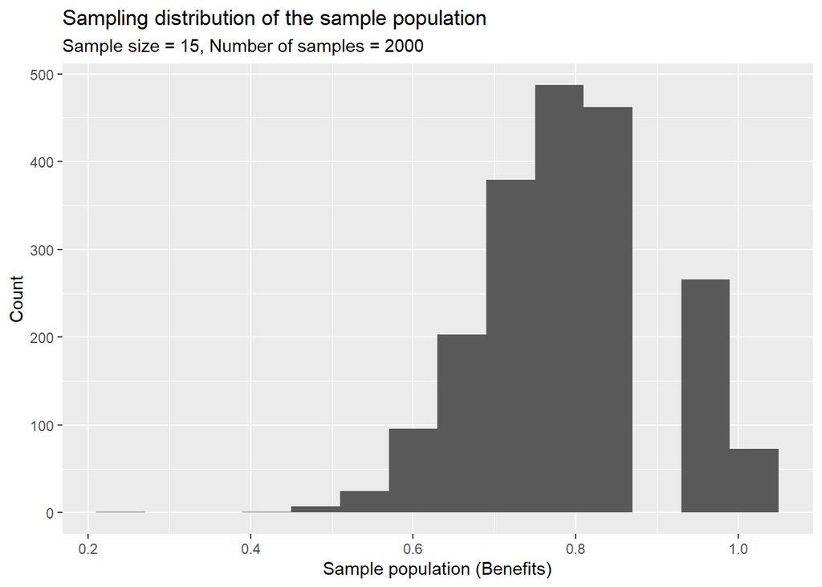

```r
ggplot(data = sample_props15, aes(x = p_hat)) +
  geom_histogram(binwidth = 0.06) +
  labs(x = "Sample population (Benefits)", y = "Count",
    title = "Sampling distribution of the sample population",
    subtitle = "Sample size = 15, Number of samples = 2000"
  )
```

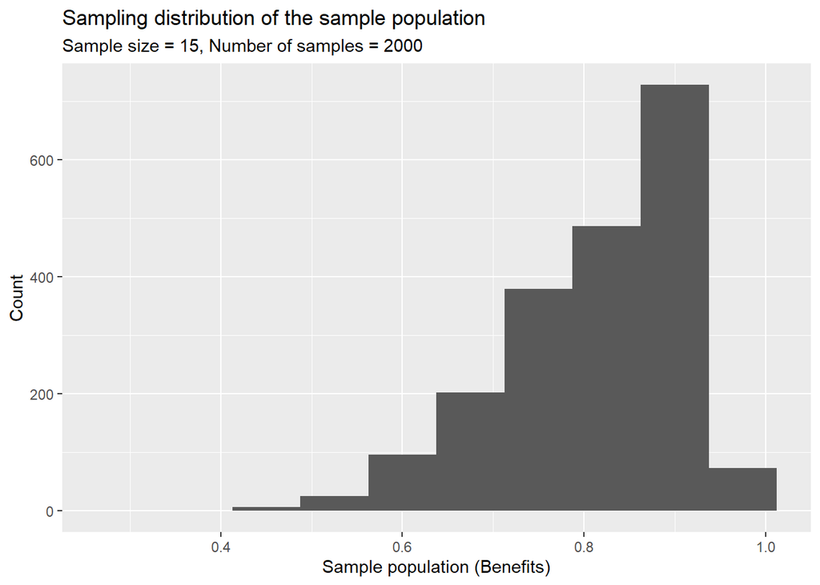

```r
ggplot(data = sample_props15, aes(x = p_hat)) +
  geom_histogram(binwidth = 0.075) +
  labs(x = "Sample population (Benefits)", y = "Count",
    title = "Sampling distribution of the sample population",
    subtitle = "Sample size = 15, Number of samples = 2000"
  )
```

```r
mosaic::favstats(sample_props15$p_hat)
```

|  | min | Q1 | median | Q3 | max | mean | sd | n | missing |
| --- | --- | --- | --- | --- | --- | --- | --- | --- | --- |
|  | 0.2666667 | 0.7333333 | 0.8 | 0.8666667 | 1 | 0.7997 | 0.1045139 | 2000 | 0 |

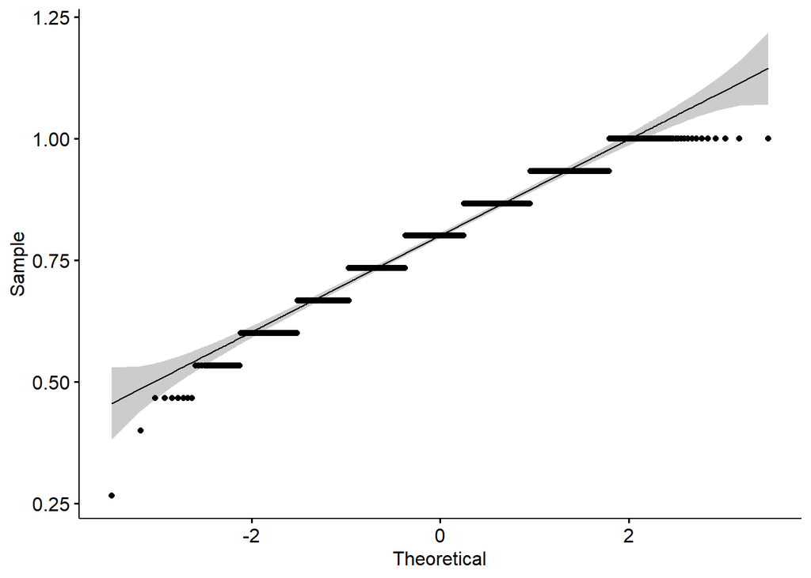

```r
ggpubr::ggqqplot(sample_props15$p_hat)
```

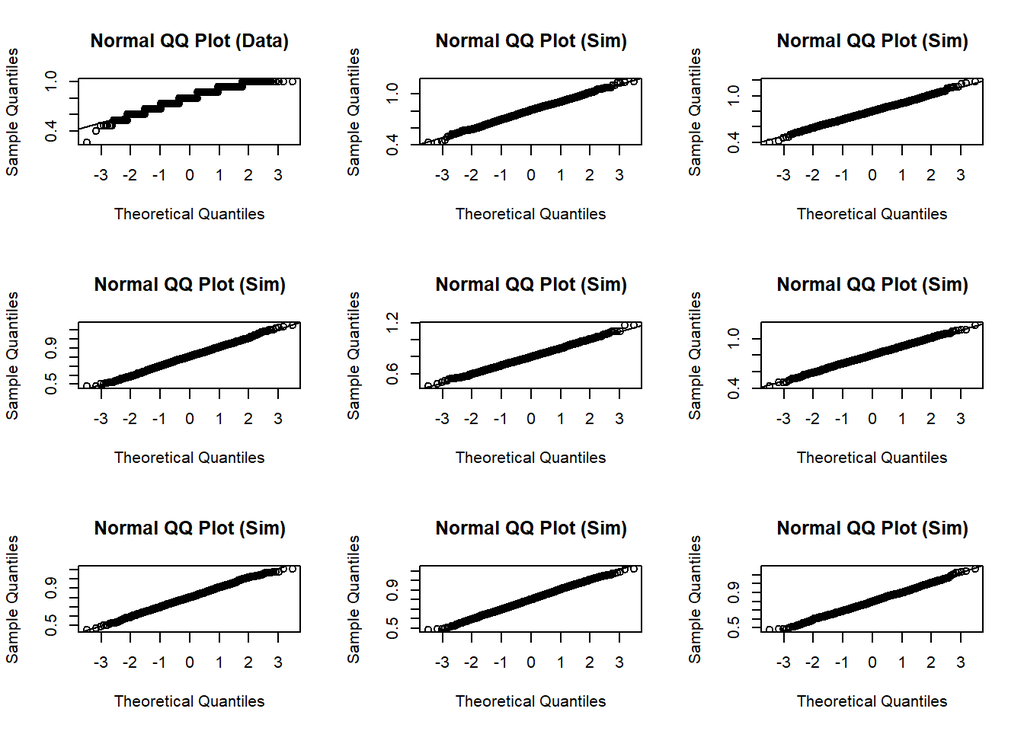

```r
DATA606::qqnormsim(sample_props15$p_hat)
```

The distributions appearance is is heavily influenced by bin size. As we see in the first histogram, the distribution appears somewhat normal but becomes more skewed in look the larger the bins become. The mean and median are nearly the same, but the quantiles are very wonky with with Q1 and Q3 existing less than one SD away from the mean. Overall I would like to call this normally distributed around .8.

9. Change your sample size from 15 to 150, then compute the sampling distribution using the same method as above, and store these proportions in a new object called `sample_props150`. Describe the shape of this sampling distribution and compare it to the sampling distribution for a sample size of 15. Based on this sampling distribution, what would you guess to be the true proportion of those who think the work scientists do enhances their lives?

```r
set.seed(1234)

sample_props150 <- global_monitor %>%
  rep_sample_n(size = 150, reps = 2000, replace = TRUE) %>%
  count(scientist_work) %>%
  mutate(p_hat = n /sum(n)) %>%
  filter(scientist_work == "Benefits")

sample_props150
```

| replicate | scientist_work | n | p_hat |
| --- | --- | --- | --- |
| 1 | Benefits | 118 | 0.7866667 |
| 2 | Benefits | 128 | 0.8533333 |
| 3 | Benefits | 119 | 0.7933333 |
| 4 | Benefits | 114 | 0.7600000 |
| 5 | Benefits | 117 | 0.7800000 |
| 6 | Benefits | 118 | 0.7866667 |
| 7 | Benefits | 116 | 0.7733333 |
| 8 | Benefits | 127 | 0.8466667 |
| 9 | Benefits | 118 | 0.7866667 |
| 10 | Benefits | 119 | 0.7933333 |

[output cut: 1990 more lines]

```r
mosaic::favstats(sample_props150$p_hat)
```

|  | min | Q1 | median | Q3 | max | mean | sd | n | missing |
| --- | --- | --- | --- | --- | --- | --- | --- | --- | --- |
|  | 0.6666667 | 0.78 | 0.8 | 0.82 | 0.9 | 0.7997533 | 0.03350772 | 2000 | 0 |

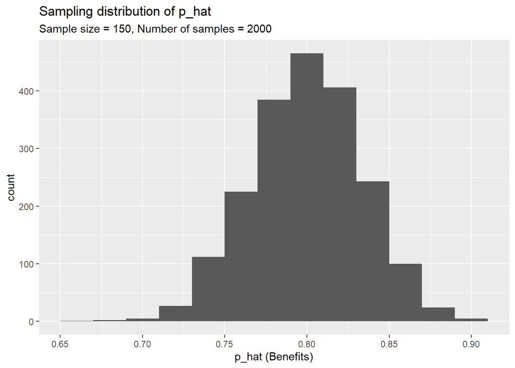

```r
ggplot(data = sample_props150, aes(x = p_hat)) +
  geom_histogram(binwidth = 0.02) +
  labs(x = "p_hat (Benefits)",
    title = "Sampling distribution of p_hat",
    subtitle = "Sample size = 150, Number of samples = 2000"
  )
```

The values are far more normal in this sample. We have a clearly normal distribution with a clear center at .8. It makes it clear that the true proportion is likely the same value, .8.

10. Of the sampling distributions from 2 and 3, which has a smaller spread? If you’re concerned with making estimates that are more often close to the true value, would you prefer a sampling distribution with a large or small spread?